# Est-Comp045

Abraham Nieto 51556

6 de septiembre de 2017

```r
x<-c(94, 197, 16, 38, 99, 141, 23)
y<-c(52, 104, 146, 10, 51, 30, 40, 27, 46)
```

1.-Usa las medias de las muestras para determinar si hay diferencias en los grupos, esto es calcula $\bar{x}-\bar{y}$.

```r
dif=abs(mean(x)-mean(y))
dif
```

```
#> [1] 30.6
```

2.-Estima el error estándar de la diferencia usando bootsrap.

```r
vBoot <- function(x){
  # x: variable de interés
  # n: número de replicaciones bootstrap
  n <- length(x)
  muestra_ix <- sample(c(1:n), size = n, replace = TRUE)
  mean(x[c(muestra_ix)])
}
x_b<-rerun(5000, vBoot(x)) %>% flatten_dbl()
y_b<-rerun(5000, vBoot(y)) %>% flatten_dbl()
sd(x_b-y_b)
```

```
#> [1] 27.1
```

3.-Corrobora tus resultados del punto anterior usando que $\hat{se}(\bar{x}-\bar{y})=\sqrt{\hat{se}(\bar{x})^2 + \hat{se}(\bar{y})^2}$

```r
x_b<-rerun(5000, vBoot(x)) %>% flatten_dbl()
y_b<-rerun(5000, vBoot(y)) %>% flatten_dbl()

sqrt((sd(x_b))**2 + (sd(y_b))**2)
```

```
#> [1] 27.1
```

4.-¿Dirías que el tratamiento incrementó la supervivencia de los ratones?

Para responder esta pregunta podemos observar el intervalo de confianza:

```r
library(ggplot2)
xbar<-mean(x)
ybar<-mean(y)
se<-sqrt((sd(x_b))**2 + (sd(y_b))**2)
IC<-c(xbar-ybar-1.96*se,xbar-ybar+1.96*se)
IC
```

```
#> [1] -22.5  83.8
```

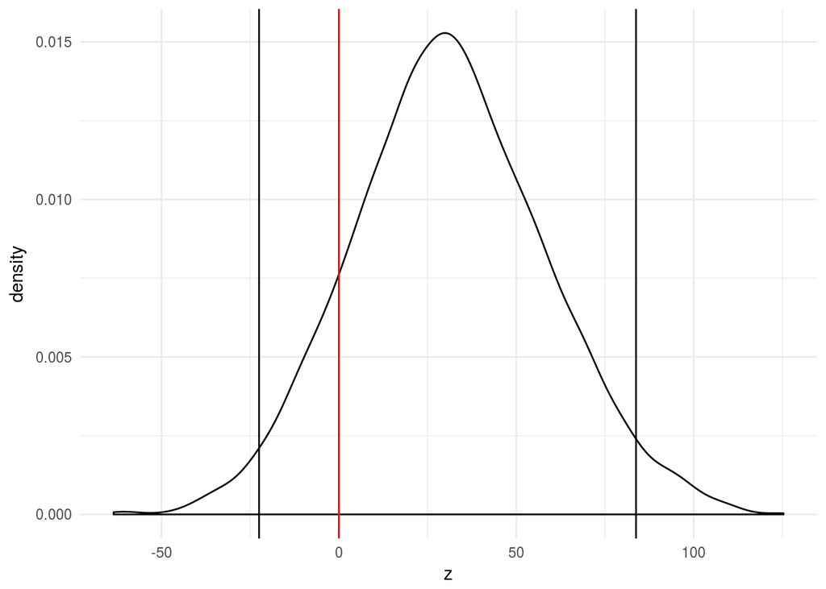

```r
df2<-data.frame(z=x_b-y_b)
ggplot(df2,aes(x=z))+geom_density()+geom_vline(xintercept=IC[1])+geom_vline(xintercept=IC[2])+geom_vline(xintercept =0,colour='red')
```

Con un 95% de confianza podemos observar que el intervalo marcado en la gráfica está entre -22 y 83 en otras palabras contiene al $0$ por tanto no podemos rechazar la hipótesis de las diferencias sean menores o iguales entonces eltratamiento NO incrementó la supervivencia de los ratones.

Ahora si revisamos en que proporción los resultados son positivos podemos calcular el % de veces que la diferencia es mayor que cero…

```r
positivo<-nrow(filter(df2,z>0))/nrow(df2)*100
positivo
```

```
#> [1] 87.5
```

5.-Supongamos que deseamos comparar los grupos usando las medianas en lugar de las medias, estima la diferencia de las medias y usa bootsrtap para estimar el error estándar de la diferencia. ¿Cuál es tu conclusión de los resultados?

```r
medBoot <- function(x){
  # x: variable de interés
  # n: número de replicaciones bootstrap
  n <- length(x)
  muestra_ix <- sample(c(1:n), size = n, replace = TRUE)
  median(x[c(muestra_ix)])
}
x_b<-rerun(5000, medBoot(x)) %>% flatten_dbl()
y_b<-rerun(5000, medBoot(y)) %>% flatten_dbl()
sd(x_b-y_b)
```

```
#> [1] 39.7
```

```r
xbar<-mean(x_b)
ybar<-mean(y_b)
se<-sd(x_b-y_b)
#error estandar
se
```

```
#> [1] 39.7
```

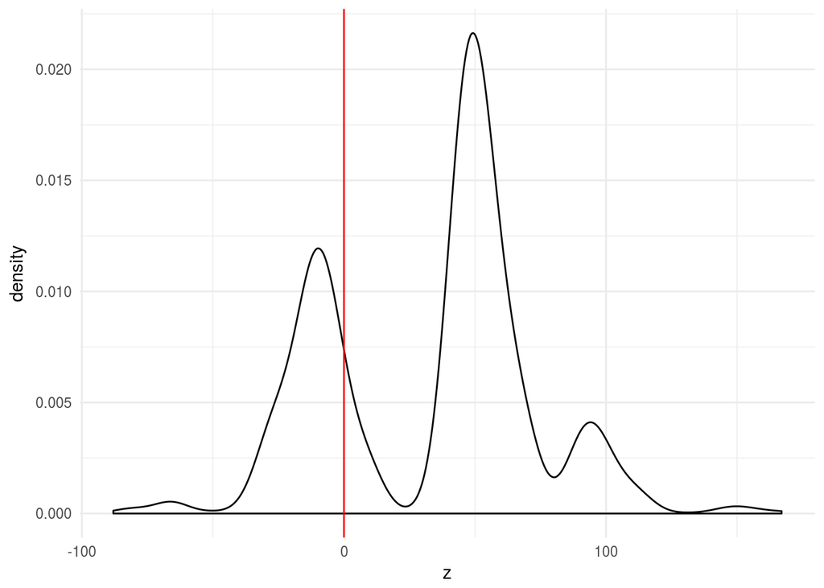

```r
df<-data.frame(z=x_b-y_b)
ggplot(df,aes(x=z))+geom_density()+geom_vline(xintercept =0,colour='red')
```

En este caso podemos ver que…

```r
positivo<-nrow(filter(df,z>0))/nrow(df)*100
positivo
```

```
#> [1] 67.5
```